# simpleRegress

Amia Little

Fall 2020

## make a simple regression model

```r
bears <- read.csv(file="BEARS.csv",header = TRUE)
#adjust factors to be factors
bears$SEX<- as.factor(bears$SEX)
bears$MONTH<- as.factor(bears$MONTH)
```

## Model LENGTH ~ NECK this is an example

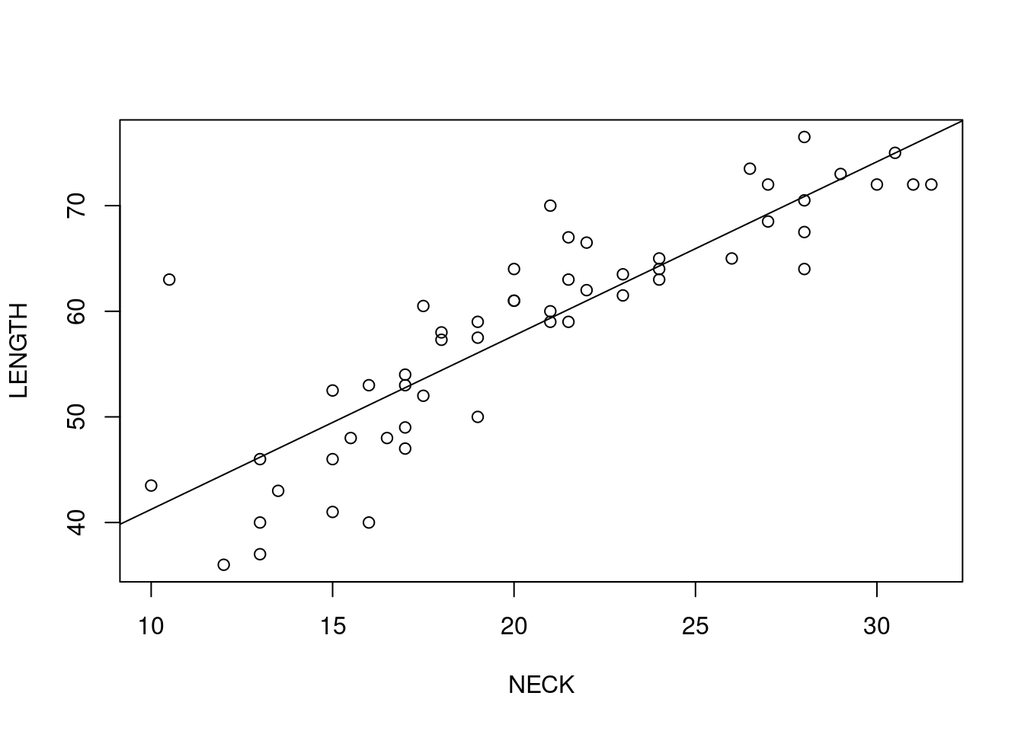

```r
simp <- lm(LENGTH~NECK,data=bears)
plot(LENGTH~NECK,data=bears)
abline(simp)
```

```r
summary.lm(simp)
```

```
##
## Call:
## lm(formula = LENGTH ~ NECK, data = bears)
##
## Residuals:
##      Min       1Q   Median       3Q      Max
## -11.1204  -3.4478  -0.0822   2.8737  20.9300
##
## Coefficients:
##             Estimate Std. Error t value Pr(>|t|)
## (Intercept)  24.7920     2.7886    8.89 5.13e-12 ***
## NECK          1.6455     0.1309   12.57  < 2e-16 ***
## ---
## Signif. codes:  0 '***' 0.001 '**' 0.01 '*' 0.05 '.' 0.1 ' ' 1
##
## Residual standard error: 5.376 on 52 degrees of freedom
## Multiple R-squared:  0.7524, Adjusted R-squared:  0.7476
## F-statistic:   158 on 1 and 52 DF,  p-value: < 2.2e-16
```

for model length~neck, adjusted r^2 = 0.75

## Compare all models that predict LENGTH other than NECK. Then order them from worst to best by its value of Adjusted-Rsquared (bigger is better), or by RSE (residual standard error) where smaller is better.

## length based on age

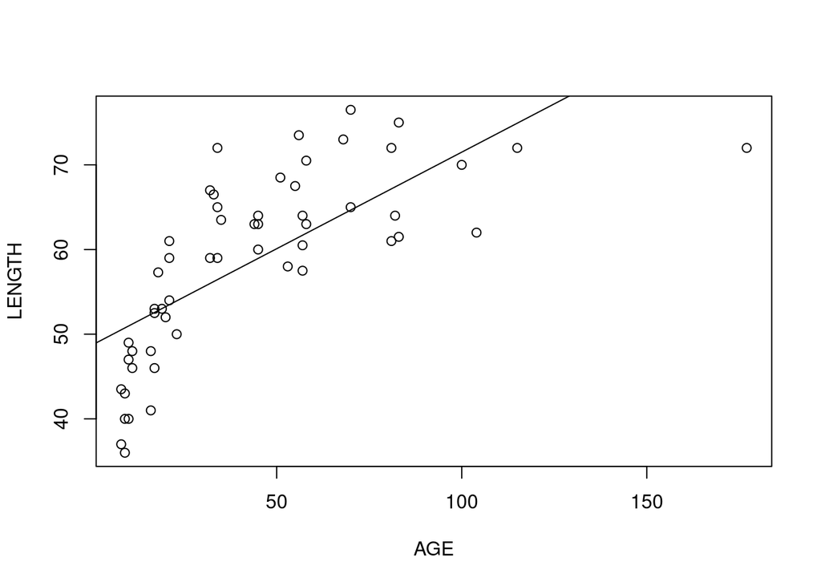

```r
simp <- lm(LENGTH~AGE,data=bears)
plot(LENGTH~AGE,data=bears)
abline(simp)
```

```r
summary.lm(simp)
```

```
##
## Call:
## lm(formula = LENGTH ~ AGE, data = bears)
##
## Residuals:
##      Min       1Q   Median       3Q      Max
## -17.0631  -4.3028   0.1595   5.4011  15.5545
##
## Coefficients:
##             Estimate Std. Error t value Pr(>|t|)
## (Intercept)  48.6903     1.6785  29.007  < 2e-16 ***
## AGE           0.2281     0.0306   7.455 9.31e-10 ***
## ---
## Signif. codes:  0 '***' 0.001 '**' 0.01 '*' 0.05 '.' 0.1 ' ' 1
##
## Residual standard error: 7.511 on 52 degrees of freedom
## Multiple R-squared:  0.5166, Adjusted R-squared:  0.5073
## F-statistic: 55.58 on 1 and 52 DF,  p-value: 9.314e-10
```

adjusted $r^2$ for age model is 0.51, this is less than the adjusted $r^2$ for neck , so this model is not as good as the neck model.

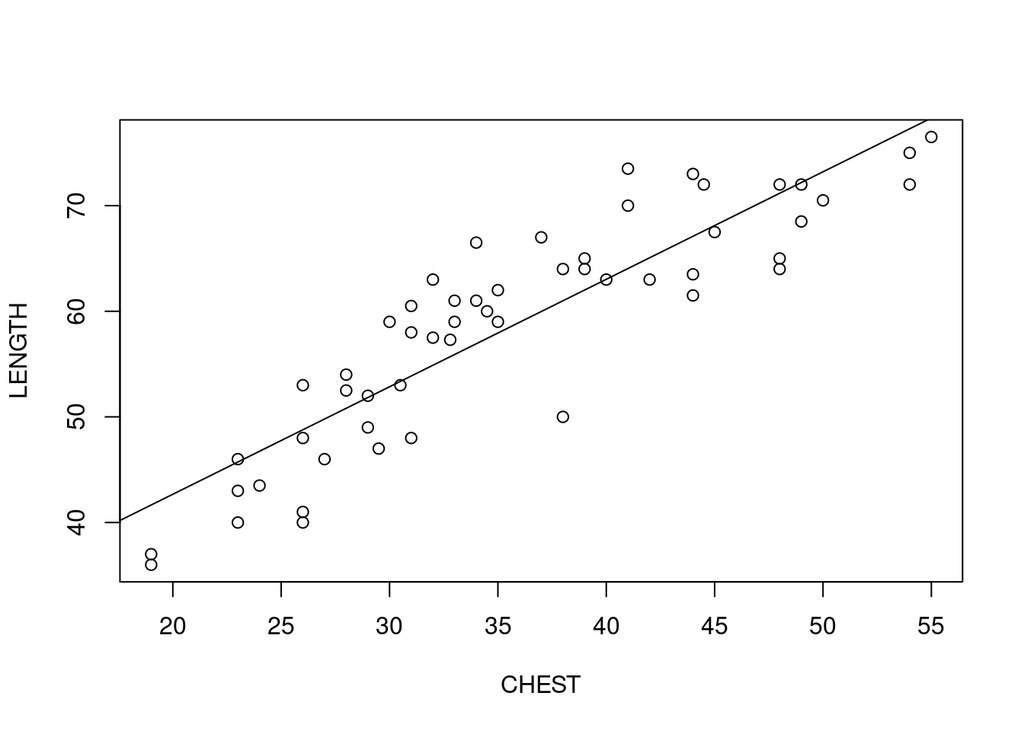

```r
chestModel<- lm(LENGTH~CHEST,data=bears)
plot(LENGTH~CHEST,data=bears)
abline(chestModel)
```

```r
summary.lm(chestModel)
```

```
##
## Call:
## lm(formula = LENGTH ~ CHEST, data = bears)
##
## Residuals:
##      Min       1Q   Median       3Q      Max
## -10.9950  -3.6672   0.0668   3.8389   9.5757
##
## Coefficients:
##             Estimate Std. Error t value Pr(>|t|)
## (Intercept) 22.32388    2.67328   8.351 3.57e-11 ***
## CHEST        1.01766    0.07255  14.027  < 2e-16 ***
## ---
## Signif. codes:  0 '***' 0.001 '**' 0.01 '*' 0.05 '.' 0.1 ' ' 1
##
## Residual standard error: 4.939 on 52 degrees of freedom
## Multiple R-squared:  0.791,  Adjusted R-squared:  0.7869
## F-statistic: 196.7 on 1 and 52 DF,  p-value: < 2.2e-16
```

adjusted $r^2$ for chest length is 0.78, this is greater than the adjusted $r^2$ for neck and age so this model is better than neck and age model.

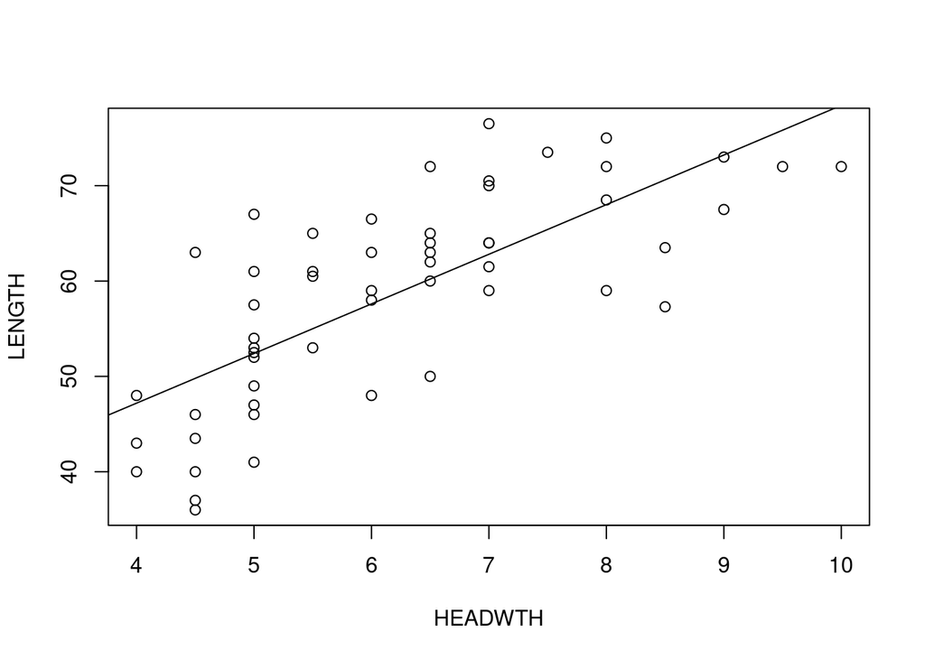

```r
simp <- lm(LENGTH~HEADWTH,data=bears)
plot(LENGTH~HEADWTH,data=bears)
abline(simp)
```

```r
summary.lm(simp)
```

```
##
## Call:
## lm(formula = LENGTH ~ HEADWTH, data = bears)
##
## Residuals:
##      Min       1Q   Median       3Q      Max
## -13.7987  -5.6379   0.4412   5.3212  14.5993
##
## Coefficients:
##             Estimate Std. Error t value Pr(>|t|)
## (Intercept)  26.3804     4.2374   6.226 8.46e-08 ***
## HEADWTH       5.2041     0.6649   7.827 2.39e-10 ***
## ---
## Signif. codes:  0 '***' 0.001 '**' 0.01 '*' 0.05 '.' 0.1 ' ' 1
##
## Residual standard error: 7.32 on 52 degrees of freedom
## Multiple R-squared:  0.5409, Adjusted R-squared:  0.5321
## F-statistic: 61.26 on 1 and 52 DF,  p-value: 2.392e-10
```

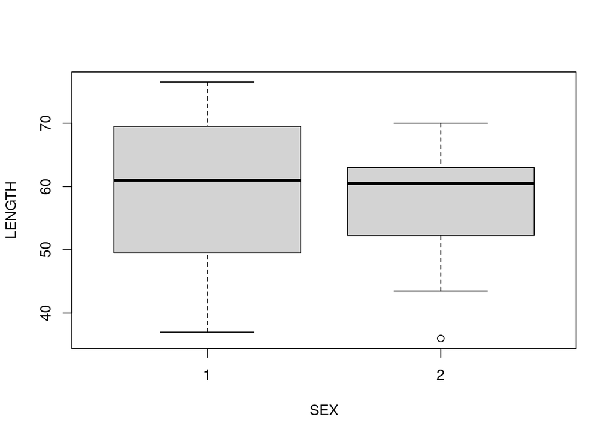

```r
simp <- lm(LENGTH~SEX,data=bears)
plot(LENGTH~SEX,data=bears)
```

```r
summary.lm(simp)
```

```
##
## Call:
## lm(formula = LENGTH ~ SEX, data = bears)
##
## Residuals:
##     Min      1Q  Median      3Q     Max
## -22.423  -8.673   3.118   7.452  17.077
##
## Coefficients:
##             Estimate Std. Error t value Pr(>|t|)
## (Intercept)   59.423      1.816  32.716   <2e-16 ***
## SEX2          -2.291      3.062  -0.748    0.458
## ---
## Signif. codes:  0 '***' 0.001 '**' 0.01 '*' 0.05 '.' 0.1 ' ' 1
##
## Residual standard error: 10.75 on 52 degrees of freedom
## Multiple R-squared:  0.01065,    Adjusted R-squared:  -0.008373
## F-statistic: 0.5599 on 1 and 52 DF,  p-value: 0.4577
```

adjusted $r^2$ for sex is 0.00, this is less than the adjusted $r^2$ of neck, headwth,chest,and age models.

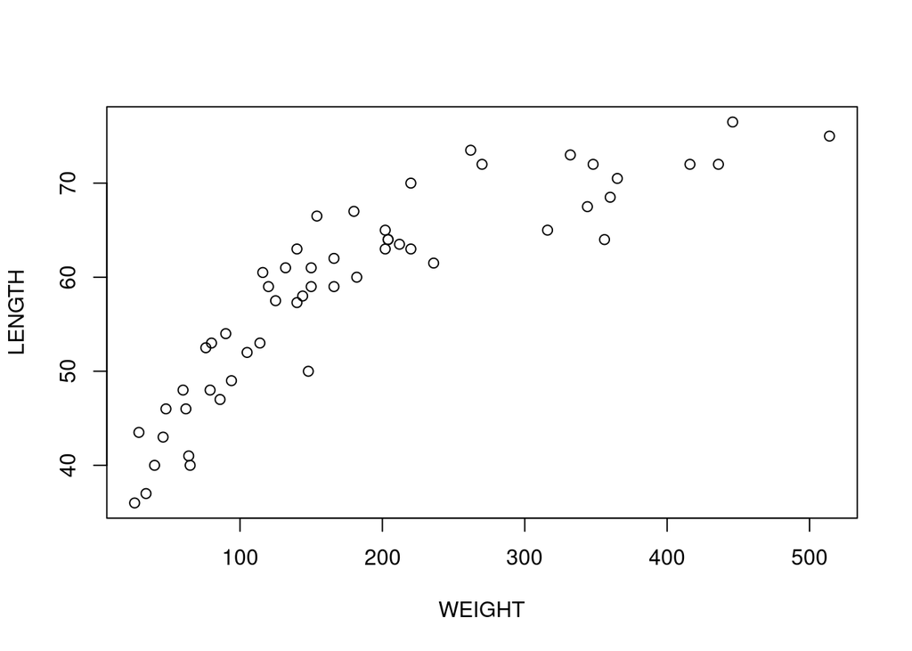

```r
simp <- lm(LENGTH~WEIGHT,data=bears)
plot(LENGTH~WEIGHT,data=bears)
```

```r
summary.lm(simp)
```

```
##
## Call:
## lm(formula = LENGTH ~ WEIGHT, data = bears)
##
## Residuals:
##     Min      1Q  Median      3Q     Max
## -10.702  -3.534   1.148   3.655  10.077
##
## Coefficients:
##              Estimate Std. Error t value Pr(>|t|)
## (Intercept) 44.727632   1.342207   33.32   <2e-16 ***
## WEIGHT       0.075942   0.006126   12.40   <2e-16 ***
## ---
## Signif. codes:  0 '***' 0.001 '**' 0.01 '*' 0.05 '.' 0.1 ' ' 1
##
## Residual standard error: 5.432 on 52 degrees of freedom
## Multiple R-squared:  0.7472, Adjusted R-squared:  0.7423
## F-statistic: 153.7 on 1 and 52 DF,  p-value: < 2.2e-16
```

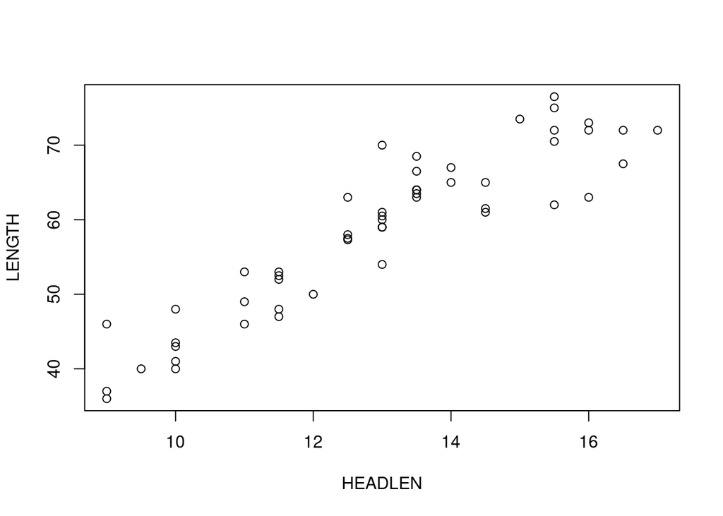

```r
simp <- lm(LENGTH~HEADLEN,data=bears)
plot(LENGTH~HEADLEN,data=bears)
```

```r
summary.lm(simp)
```

```
##
## Call:
## lm(formula = LENGTH ~ HEADLEN, data = bears)
##
## Residuals:
##     Min      1Q  Median      3Q     Max
## -9.6037 -3.6005  0.2942  2.7500 11.1708
##
## Coefficients:
##             Estimate Std. Error t value Pr(>|t|)
## (Intercept)  -0.8600     3.5618  -0.241     0.81
## HEADLEN       4.5915     0.2713  16.922   <2e-16 ***
## ---
## Signif. codes:  0 '***' 0.001 '**' 0.01 '*' 0.05 '.' 0.1 ' ' 1
##
## Residual standard error: 4.235 on 52 degrees of freedom
## Multiple R-squared:  0.8463, Adjusted R-squared:  0.8434
## F-statistic: 286.3 on 1 and 52 DF,  p-value: < 2.2e-16
```

adjusted $r^2$ for headlen is 0.84 which is greater than all model so it is the best model.

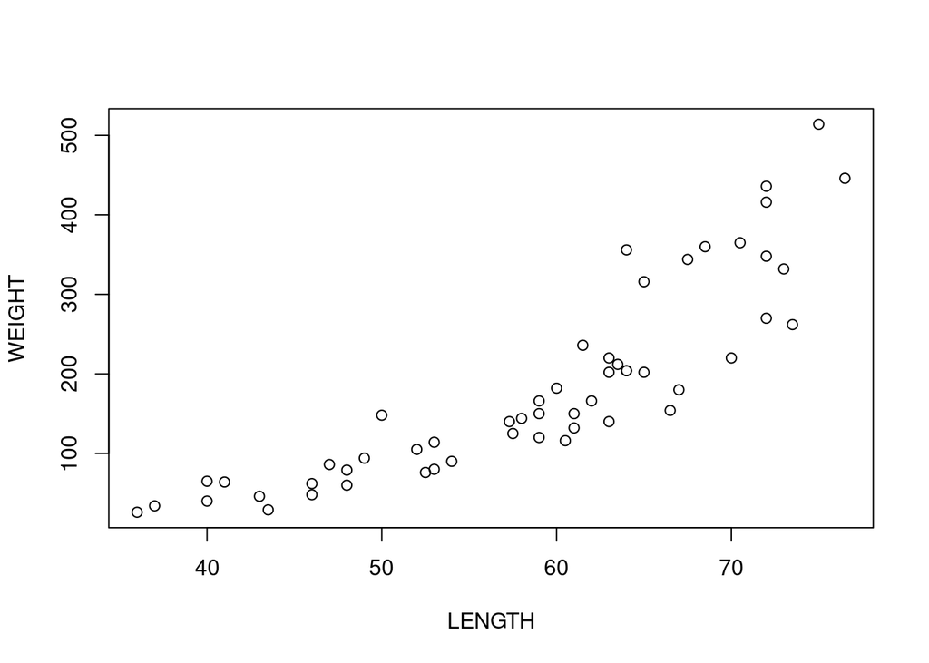

```r
simp <- lm(WEIGHT~LENGTH,data=bears)
plot(WEIGHT~LENGTH,data=bears)
```

```r
summary.lm(simp)
```

```
##
## Call:
## lm(formula = WEIGHT ~ LENGTH, data = bears)
##
## Residuals:
##     Min      1Q  Median      3Q     Max
## -106.45  -46.17  -13.21   47.49  169.92
##
## Coefficients:
##              Estimate Std. Error t value Pr(>|t|)
## (Intercept) -393.8391    47.2752  -8.331 3.83e-11 ***
## LENGTH         9.8390     0.7936  12.397  < 2e-16 ***
## ---
## Signif. codes:  0 '***' 0.001 '**' 0.01 '*' 0.05 '.' 0.1 ' ' 1
##
## Residual standard error: 61.83 on 52 degrees of freedom
## Multiple R-squared:  0.7472, Adjusted R-squared:  0.7423
## F-statistic: 153.7 on 1 and 52 DF,  p-value: < 2.2e-16
```